# Course: Data Science

# CA3-Introduction to Data Science

# Team memebers:

# Shahzad Momayez-sid:810100272

# Mohammad Amanlou-sid:810100084

# Amir Mahdi Farzaneh-sid:810100194

```python
from pyspark.sql import SparkSession

# Get existed or Create new SparkSession
spark = SparkSession.builder.appName('Spark Demo').master('local[*]').getOrCreate()
spark
```

**SparkSession - in-memory**

**SparkContext**

[Spark UI](http://DESKTOP-MSJ4V9T:4040)

**Version**

`v3.5.1`

**Master**

`local[*]`

**AppName**

`Spark Demo`

```python
from pyspark.sql import functions as F
```

# Warm Up!

## Q1

```python
data_path = 'stocks.csv'
df = spark.read.csv(data_path, header=True, inferSchema=True)
```

## Q2

```python
df.printSchema()
```

```
root
 |-- Date: date (nullable = true)
 |-- Open: double (nullable = true)
 |-- High: double (nullable = true)
 |-- Low: double (nullable = true)
 |-- Close: double (nullable = true)
 |-- Volume: integer (nullable = true)
 |-- Adj Close: double (nullable = true)
```

## Q3

```python
df.where(df['Close']<500).select(df.Open, df.Close, df.Volume).show(10)
```

```
+------------------+------------------+---------+
|              Open|             Close|   Volume|
+------------------+------------------+---------+
|        213.429998|        214.009998|123432400|
|        214.599998|        214.379993|150476200|
|        214.379993|        210.969995|138040000|
|            211.75|            210.58|119282800|
|        210.299994|211.98000499999998|111902700|
|212.79999700000002|210.11000299999998|115557400|
|209.18999499999998|        207.720001|148614900|
|        207.870005|        210.650002|151473000|
|210.11000299999998|            209.43|108223500|
|210.92999500000002|            205.93|148516900|
+------------------+------------------+---------+
only showing top 10 rows
```

## Q4

```python
df.where((F.col('Close')<200) & (F.col('Open') > 200)).show(10)
```

```
+----------+------------------+----------+----------+----------+---------+------------------+
|      Date|              Open|      High|       Low|     Close|   Volume|         Adj Close|
+----------+------------------+----------+----------+----------+---------+------------------+
|2010-01-22|206.78000600000001|207.499996|    197.16|    197.75|220441900|         25.620401|
|2010-01-28|        204.930004|205.500004|198.699995|199.289995|293375600|25.819922000000002|
|2010-01-29|        201.079996|202.199995|190.250002|192.060003|311488100|         24.883208|
+----------+------------------+----------+----------+----------+---------+------------------+
```

## Q5

```python
df2 = df.withColumn('Year',F.year(F.to_timestamp('Date', 'dd/MM/yyyy')))
```

```python
df2.show()
```

```
+----------+------------------+------------------+------------------+------------------+---------+------------------+----+
|      Date|              Open|              High|               Low|             Close|   Volume|         Adj Close|Year|
+----------+------------------+------------------+------------------+------------------+---------+------------------+----+
|2010-01-04|        213.429998|        214.499996|212.38000099999996|        214.009998|123432400|         27.727039|2010|
|2010-01-05|        214.599998|        215.589994|        213.249994|        214.379993|150476200|27.774976000000002|2010|
|2010-01-06|        214.379993|            215.23|        210.750004|        210.969995|138040000|27.333178000000004|2010|
|2010-01-07|            211.75|        212.000006|        209.050005|            210.58|119282800|          27.28265|2010|
|2010-01-08|        210.299994|        212.000006|209.06000500000002|211.98000499999998|111902700|         27.464034|2010|
|2010-01-11|212.79999700000002|        213.000002|        208.450005|210.11000299999998|115557400|         27.221758|2010|
|2010-01-12|209.18999499999998|209.76999500000002|        206.419998|        207.720001|148614900|          26.91211|2010|
|2010-01-13|        207.870005|210.92999500000002|        204.099998|        210.650002|151473000|          27.29172|2010|
|2010-01-14|210.11000299999998|210.45999700000002|        209.020004|            209.43|108223500|         27.133657|2010|
|2010-01-15|210.92999500000002|211.59999700000003|        205.869999|            205.93|148516900|26.680197999999997|2010|
|2010-01-19|        208.330002|215.18999900000003|        207.240004|        215.039995|182501900|27.860484999999997|2010|
|2010-01-20|        214.910006|        215.549994|        209.500002|            211.73|153038200|         27.431644|2010|
|2010-01-21|        212.079994|213.30999599999998|        207.210003|        208.069996|152038600|         26.957455|2010|
|2010-01-22|206.78000600000001|        207.499996|            197.16|            197.75|220441900|         25.620401|2010|
|2010-01-25|202.51000200000001|        204.699999|        200.190002|        203.070002|266424900|26.309658000000002|2010|
|2010-01-26|205.95000100000001|        213.710005|        202.580004|        205.940001|466777500|         26.681494|2010|
|2010-01-27|        206.849995|            210.58|        199.530001|        207.880005|430642100|26.932840000000002|2010|
|2010-01-28|        204.930004|        205.500004|        198.699995|        199.289995|293375600|25.819922000000002|2010|
|2010-01-29|        201.079996|        202.199995|        190.250002|        192.060003|311488100|         24.883208|2010|
|2010-02-01|192.36999699999998|             196.0|191.29999899999999|        194.729998|187469100|         25.229131|2010|
+----------+------------------+------------------+------------------+------------------+---------+------------------+----+
only showing top 20 rows
```

## Q6

```python
df2.groupBy('Year').agg(F.min('Volume').alias('minVolume')).show()
```

```
+----+---------+
|Year|minVolume|
+----+---------+
|2015| 13046400|
|2013| 41888700|
|2014| 14479600|
|2012| 43938300|
|2016| 11475900|
|2010| 39373600|
|2011| 44915500|
+----+---------+
```

## Q7

```python
df3 = df2.withColumn('Month',F.month(F.to_timestamp('Date', 'dd/MM/yyyy')))
```

```python
df3.show(10)
```

```
+----------+------------------+------------------+------------------+------------------+---------+------------------+----+-----+
|      Date|              Open|              High|               Low|             Close|   Volume|         Adj Close|Year|Month|
+----------+------------------+------------------+------------------+------------------+---------+------------------+----+-----+
|2010-01-04|        213.429998|        214.499996|212.38000099999996|        214.009998|123432400|         27.727039|2010|    1|
|2010-01-05|        214.599998|        215.589994|        213.249994|        214.379993|150476200|27.774976000000002|2010|    1|
|2010-01-06|        214.379993|            215.23|        210.750004|        210.969995|138040000|27.333178000000004|2010|    1|
|2010-01-07|            211.75|        212.000006|        209.050005|            210.58|119282800|          27.28265|2010|    1|
|2010-01-08|        210.299994|        212.000006|209.06000500000002|211.98000499999998|111902700|         27.464034|2010|    1|
|2010-01-11|212.79999700000002|        213.000002|        208.450005|210.11000299999998|115557400|         27.221758|2010|    1|
|2010-01-12|209.18999499999998|209.76999500000002|        206.419998|        207.720001|148614900|          26.91211|2010|    1|
|2010-01-13|        207.870005|210.92999500000002|        204.099998|        210.650002|151473000|          27.29172|2010|    1|
|2010-01-14|210.11000299999998|210.45999700000002|        209.020004|            209.43|108223500|         27.133657|2010|    1|
|2010-01-15|210.92999500000002|211.59999700000003|        205.869999|            205.93|148516900|26.680197999999997|2010|    1|
+----------+------------------+------------------+------------------+------------------+---------+------------------+----+-----+
only showing top 10 rows
```

```python
df4 = df3.withColumn('Year/Month',F.concat('Year', F.lit("/"), 'Month'))
```

```python
df4.show()
```

```
+----------+------------------+------------------+------------------+------------------+---------+------------------+----+-----+----------+
|      Date|              Open|              High|               Low|             Close|   Volume|         Adj Close|Year|Month|Year/Month|
+----------+------------------+------------------+------------------+------------------+---------+------------------+----+-----+----------+
|2010-01-04|        213.429998|        214.499996|212.38000099999996|        214.009998|123432400|         27.727039|2010|    1|    2010/1|
|2010-01-05|        214.599998|        215.589994|        213.249994|        214.379993|150476200|27.774976000000002|2010|    1|    2010/1|
|2010-01-06|        214.379993|            215.23|        210.750004|        210.969995|138040000|27.333178000000004|2010|    1|    2010/1|
|2010-01-07|            211.75|        212.000006|        209.050005|            210.58|119282800|          27.28265|2010|    1|    2010/1|
|2010-01-08|        210.299994|        212.000006|209.06000500000002|211.98000499999998|111902700|         27.464034|2010|    1|    2010/1|
|2010-01-11|212.79999700000002|        213.000002|        208.450005|210.11000299999998|115557400|         27.221758|2010|    1|    2010/1|
|2010-01-12|209.18999499999998|209.76999500000002|        206.419998|        207.720001|148614900|          26.91211|2010|    1|    2010/1|
|2010-01-13|        207.870005|210.92999500000002|        204.099998|        210.650002|151473000|          27.29172|2010|    1|    2010/1|
|2010-01-14|210.11000299999998|210.45999700000002|        209.020004|            209.43|108223500|         27.133657|2010|    1|    2010/1|
|2010-01-15|210.92999500000002|211.59999700000003|        205.869999|            205.93|148516900|26.680197999999997|2010|    1|    2010/1|
|2010-01-19|        208.330002|215.18999900000003|        207.240004|        215.039995|182501900|27.860484999999997|2010|    1|    2010/1|
|2010-01-20|        214.910006|        215.549994|        209.500002|            211.73|153038200|         27.431644|2010|    1|    2010/1|
|2010-01-21|        212.079994|213.30999599999998|        207.210003|        208.069996|152038600|         26.957455|2010|    1|    2010/1|
|2010-01-22|206.78000600000001|        207.499996|            197.16|            197.75|220441900|         25.620401|2010|    1|    2010/1|
|2010-01-25|202.51000200000001|        204.699999|        200.190002|        203.070002|266424900|26.309658000000002|2010|    1|    2010/1|
|2010-01-26|205.95000100000001|        213.710005|        202.580004|        205.940001|466777500|         26.681494|2010|    1|    2010/1|
|2010-01-27|        206.849995|            210.58|        199.530001|        207.880005|430642100|26.932840000000002|2010|    1|    2010/1|
|2010-01-28|        204.930004|        205.500004|        198.699995|        199.289995|293375600|25.819922000000002|2010|    1|    2010/1|
|2010-01-29|        201.079996|        202.199995|        190.250002|        192.060003|311488100|         24.883208|2010|    1|    2010/1|
|2010-02-01|192.36999699999998|             196.0|191.29999899999999|        194.729998|187469100|         25.229131|2010|    2|    2010/2|
+----------+------------------+------------------+------------------+------------------+---------+------------------+----+-----+----------+
only showing top 20 rows
```

```python
df4.groupBy('Year/Month').agg(F.max('Low').alias('maxLow')).show()
```

```
+----------+------------------+
|Year/Month|            maxLow|
+----------+------------------+
|    2013/6|447.38999900000005|
|    2011/9|        412.000004|
|    2014/8|        102.199997|
|    2016/4|111.33000200000001|
|    2010/2|        202.000004|
|   2015/11|        121.620003|
|   2012/11|        594.170021|
|    2012/4| 626.0000150000001|
|    2014/6|        644.470024|
|    2010/1|        213.249994|
|    2011/2|             360.5|
|    2014/2| 545.6099780000001|
|    2011/1|        344.440006|
|    2010/5|        262.880009|
|   2011/12|        403.490009|
|   2013/11|        547.809975|
|   2011/11|        401.560005|
|    2015/2|        131.169998|
|   2014/12|        115.290001|
|   2010/10|        314.289997|
+----------+------------------+
only showing top 20 rows
```

## Q8

```python
df.agg(F.round(F.mean('High'), 2).alias('Avg'), F.round(F.std('High'), 2).alias('Std')).show()
```

```
+------+-----+
|   Avg|  Std|
+------+-----+
|315.91|186.9|
+------+-----+
```

# Main Task

### First checking

```python
!pip install pyspark
```

```
     ━━━━━━━━━━━━━━━━━━━━━━━━━━━━━━━━━━━━━━━━ 317.0/317.0 MB 1.5 MB/s eta 0:00:00
  Preparing metadata (setup.py) ... done
```

```python
import matplotlib.pyplot as plt
from pyspark.sql import SparkSession
import matplotlib.pyplot as plt
from pyspark.sql.functions import count, when, isnull
from pyspark.sql.functions import isnan, when, count, col, corr , desc
from pyspark.sql import functions as F
from pyspark.sql.functions import to_date, month, year
from pyspark.sql import SparkSession
from pyspark.sql.functions import udf
from pyspark.sql.types import DateType
import datetime
```

```python
spark = SparkSession.builder.config("spark.sql.legacy.timeParserPolicy", "LEGACY").getOrCreate()
```

```python
from google.colab import drive
drive.mount('/content/drive')
df = spark.read.parquet("/content/drive/My Drive/spotify.parquet")
```

```python
df.printSchema()
```

```
root
 |-- id: string (nullable = true)
 |-- name: string (nullable = true)
 |-- album: string (nullable = true)
 |-- album_id: string (nullable = true)
 |-- artists: string (nullable = true)
 |-- artist_ids: string (nullable = true)
 |-- track_number: long (nullable = true)
 |-- disc_number: long (nullable = true)
 |-- explicit: boolean (nullable = true)
 |-- danceability: double (nullable = true)
 |-- energy: double (nullable = true)
 |-- key: long (nullable = true)
 |-- loudness: double (nullable = true)
 |-- mode: long (nullable = true)
 |-- speechiness: double (nullable = true)
 |-- acousticness: double (nullable = true)
 |-- instrumentalness: double (nullable = true)
 |-- liveness: double (nullable = true)
 |-- valence: double (nullable = true)
 |-- tempo: double (nullable = true)
 |-- duration_ms: long (nullable = true)
 |-- time_signature: double (nullable = true)
 |-- year: long (nullable = true)
 |-- release_date: string (nullable = true)
```

```python
df.show(5)
```

```
+--------------------+--------------------+--------------------+--------------------+--------------------+--------------------+------------+-----------+--------+------------+------+---+------------------+----+-----------+------------+----------------+--------+-------+-------+-----------+------------…
|                  id|                name|               album|            album_id|             artists|          artist_ids|track_number|disc_number|explicit|danceability|energy|key|          loudness|mode|speechiness|acousticness|instrumentalness|liveness|valence|  tempo|duration_ms|time_signatu…
+--------------------+--------------------+--------------------+--------------------+--------------------+--------------------+------------+-----------+--------+------------+------+---+------------------+----+-----------+------------+----------------+--------+-------+-------+-----------+------------…
|7lmeHLHBe4nmXzuXc...|             Testify|The Battle Of Los...|2eia0myWFgoHuttJy...|['Rage Against Th...|['2d0hyoQ5ynDBnkv...|           1|          1|   false|        0.47| 0.978|  7|            -5.399|   1|     0.0727|      0.0261|         1.09E-5|   0.356|  0.503|117.906|     210133|           4…
|1wsRitfRRtWyEapl0...|     Guerrilla Radio|The Battle Of Los...|2eia0myWFgoHuttJy...|['Rage Against Th...|['2d0hyoQ5ynDBnkv...|           2|          1|    true|       0.599| 0.957| 11|-5.763999999999999|   1|      0.188|      0.0129|         7.06E-5|   0.155|  0.489| 103.68|     206200|           4…
|1hR0fIFK2qRG3f3RF...|    Calm Like a Bomb|The Battle Of Los...|2eia0myWFgoHuttJy...|['Rage Against Th...|['2d0hyoQ5ynDBnkv...|           3|          1|   false|       0.315|  0.97|  7|            -5.424|   1|      0.483|      0.0234|         2.03E-6|   0.122|   0.37|149.749|     298893|           4…
|2lbASgTSoDO7MTuLA...|           Mic Check|The Battle Of Los...|2eia0myWFgoHuttJy...|['Rage Against Th...|['2d0hyoQ5ynDBnkv...|           4|          1|    true|        0.44| 0.967| 11|             -5.83|   0|      0.237|       0.163|         3.64E-6|   0.121|  0.574| 96.752|     213640|           4…
|1MQTmpYOZ6fcMQc56...|Sleep Now In the ...|The Battle Of Los...|2eia0myWFgoHuttJy...|['Rage Against Th...|['2d0hyoQ5ynDBnkv...|           5|          1|   false|       0.426| 0.929|  2|            -6.729|   1|     0.0701|     0.00162|           0.105|  0.0789|  0.539|127.059|     205600|           4…
+--------------------+--------------------+--------------------+--------------------+--------------------+--------------------+------------+-----------+--------+------------+------+---+------------------+----+-----------+------------+----------------+--------+-------+-------+-----------+------------…
only showing top 5 rows
```

```python
df.take(5)
```

```
[Row(id='7lmeHLHBe4nmXzuXc0HDjk', name='Testify', album='The Battle Of Los Angeles', album_id='2eia0myWFgoHuttJytCxgX', artists="['Rage Against The Machine']", artist_ids="['2d0hyoQ5ynDBnkvAbJKORj']", track_number=1, disc_number=1, explicit=False, danceability=0.47, energy=0.978, key=7, loudness=-5.…
 Row(id='1wsRitfRRtWyEapl0q22o8', name='Guerrilla Radio', album='The Battle Of Los Angeles', album_id='2eia0myWFgoHuttJytCxgX', artists="['Rage Against The Machine']", artist_ids="['2d0hyoQ5ynDBnkvAbJKORj']", track_number=2, disc_number=1, explicit=True, danceability=0.599, energy=0.957, key=11, lou…
 Row(id='1hR0fIFK2qRG3f3RF70pb7', name='Calm Like a Bomb', album='The Battle Of Los Angeles', album_id='2eia0myWFgoHuttJytCxgX', artists="['Rage Against The Machine']", artist_ids="['2d0hyoQ5ynDBnkvAbJKORj']", track_number=3, disc_number=1, explicit=False, danceability=0.315, energy=0.97, key=7, lou…
 Row(id='2lbASgTSoDO7MTuLAXlTW0', name='Mic Check', album='The Battle Of Los Angeles', album_id='2eia0myWFgoHuttJytCxgX', artists="['Rage Against The Machine']", artist_ids="['2d0hyoQ5ynDBnkvAbJKORj']", track_number=4, disc_number=1, explicit=True, danceability=0.44, energy=0.967, key=11, loudness=-…
 Row(id='1MQTmpYOZ6fcMQc56Hdo7T', name='Sleep Now In the Fire', album='The Battle Of Los Angeles', album_id='2eia0myWFgoHuttJytCxgX', artists="['Rage Against The Machine']", artist_ids="['2d0hyoQ5ynDBnkvAbJKORj']", track_number=5, disc_number=1, explicit=False, danceability=0.426, energy=0.929, key=…
```

```python
df.describe().show()
```

```
+-------+--------------------+----------+---------------+--------------------+---------------------------+--------------------+-----------------+-------------------+-------------------+-------------------+-----------------+-------------------+-------------------+-------------------+-----------------…
|summary|                  id|      name|          album|            album_id|                    artists|          artist_ids|     track_number|        disc_number|       danceability|             energy|              key|           loudness|               mode|        speechiness|       acousticne…
+-------+--------------------+----------+---------------+--------------------+---------------------------+--------------------+-----------------+-------------------+-------------------+-------------------+-----------------+-------------------+-------------------+-------------------+-----------------…
|  count|             1204025|   1204022|        1204014|             1204025|                    1204025|             1204025|          1204025|            1204025|            1204025|            1204025|          1204025|            1204025|            1204025|            1204025|            12040…
|   mean|                NULL|       NaN|       Infinity|                NULL|                       NULL|                NULL|7.656351819937294| 1.0559058159091381|0.49305652179149567| 0.5095362861749997|5.194151284234131|-11.808702928095125| 0.6714594796619672|0.08438219123357689|0.446751098196852…
| stddev|                NULL|       NaN|            NaN|                NULL|                       NULL|                NULL|5.994977426554823|0.29537516799866304| 0.1896694028575742|0.29468391295221086|3.536730782291117| 6.9821316109798195|0.46968269081835023|0.11599137055178492|0.385201418801080…
|    min|0001Lyv0YTjkZSqzT...|         !|              !|0008WZMLnvEBVnq41...|            ["'63 Burnout"]|['000IaWMr5wgahZN...|                1|                  1|                0.0|                0.0|                0|              -60.0|                  0|                0.0|                0…
|    max|7zzzxEQAsiuIimY7A...|what Baby|행복(Happiness)|7zzz0Fqahwtd6jd2B...|['Ｏｃｅａｎ Ｓｈｏｒｅｓ']|['7zyhnskTdKPIbiA...|               50|                 13|                1.0|                1.0|               11|              7.234|                  1|              0.969|              0.996|           …
+-------+--------------------+----------+---------------+--------------------+---------------------------+--------------------+-----------------+-------------------+-------------------+-------------------+-----------------+-------------------+-------------------+-------------------+-----------------…
```

```python
numerical_cols = ['danceability', 'energy', 'tempo']
stats = df.select(numerical_cols).describe()
stats.show()
```

```
+-------+-------------------+-------------------+------------------+
|summary|       danceability|             energy|             tempo|
+-------+-------------------+-------------------+------------------+
|  count|            1204025|            1204025|           1204025|
|   mean|0.49305652179149567| 0.5095362861749997| 117.6343518099754|
| stddev| 0.1896694028575742|0.29468391295221086| 30.93704666111428|
|    min|                0.0|                0.0|               0.0|
|    max|                1.0|                1.0|248.93400000000003|
+-------+-------------------+-------------------+------------------+
```

### Correlation

```python
numeric_columns = [col for col in df.columns if (df.select(col).dtypes[0][1] != 'boolean' and df.select(col).dtypes[0][1] != "str" and df.select(col).dtypes[0][1] != "string")]
# Compute correlation between numerical columns
correlation_matrix = df.select([corr(col1, col2).alias(col1 + '__' + col2) for col1 in numeric_columns for col2 in numeric_columns if col1 != col2]).toPandas()
print("Correlation matrix:")
print(correlation_matrix)
```

```
Correlation matrix:
   track_number__disc_number  track_number__danceability  \
0                  -0.005175                   -0.041665

   track_number__energy  track_number__key  track_number__loudness  \
0             -0.124871          -0.002315               -0.144221

   track_number__mode  track_number__speechiness  track_number__acousticness  \
0            0.012315                   0.045695                    0.127427

   track_number__instrumentalness  track_number__liveness  ...  \
0                        0.037038                0.018261  ...

   year__loudness  year__mode  year__speechiness  year__acousticness  \
0        0.172585    -0.05467           0.058225            -0.15155

   year__instrumentalness  year__liveness  year__valence  year__tempo  \
0               -0.007839        -0.01536      -0.053827     0.039672

   year__duration_ms  year__time_signature
0          -0.008671              0.029259

[1 rows x 240 columns]
```

### count missing values

```python
# Check for missing values
missing_values = df.select([count(when(col(c).isNull() | (col(c) == ''), c)).alias(c) for c in df.columns]).toPandas().T
print("Missing values:")
print(missing_values)
```

```
Missing values:
                   0
id                 0
name               3
album             11
album_id           0
artists            0
artist_ids         0
track_number       0
disc_number        0
explicit           0
danceability       0
energy             0
key                0
loudness           0
mode               0
speechiness        0
acousticness       0
instrumentalness   0
liveness           0
valence            0
tempo              0
duration_ms        0
time_signature     0
year               0
release_date       0
```

### Count some groups

```python
artist_counts = df.groupBy('artists').count().orderBy('count', ascending=False)
album_counts = df.groupBy('album').count().orderBy('count', ascending=False)
release_date_counts = df.groupBy('release_date').count().orderBy('count', ascending=False)
year_counts = df.groupBy('year').count().orderBy('count', ascending=False)
```

```python
missing_values = df.select([count(when(isnull(c), c)).alias(c) for c in df.columns])
missing_values.toPandas
```

[output not shown]

[output not shown]

```python
artist_counts.show()
```

```
+--------------------+-----+
|             artists|count|
+--------------------+-----+
| ['Various Artists']| 1753|
|['Vitamin String ...| 1577|
| ['Aretha Franklin']| 1209|
|['The City of Pra...| 1042|
|["Dan Gibson's So...|  997|
|       ['Bob Dylan']|  913|
|        ['The Fall']|  812|
|["Pickin' On Seri...|  774|
|    ['Dolly Parton']|  747|
|['Guided By Voices']|  739|
|  ['Dionne Warwick']|  728|
|   ['Fleetwood Mac']|  696|
|   ['Elvis Presley']|  645|
|['Revolt Producti...|  627|
|['Mannheim Steamr...|  619|
|     ['Udo Jürgens']|  615|
|  ['Emmylou Harris']|  607|
|   ['Barry Manilow']|  605|
|      ['Al Jarreau']|  597|
| ['Grant Macdonald']|  587|
+--------------------+-----+
only showing top 20 rows
```

```python
album_counts.show()
```

```
+--------------------+-----+
|               album|count|
+--------------------+-----+
|       Greatest Hits| 1800|
|                Live|  872|
|      The Collection|  343|
|          Love Songs|  337|
|          Super Hits|  330|
|Platinum & Gold C...|  300|
|         The Best Of|  280|
|RCA 100 Años de M...|  280|
|                  II|  278|
|     Handel: Messiah|  268|
|             Best Of|  255|
|The Definitive Co...|  249|
|                Home|  240|
|                 One|  230|
|                 III|  227|
|16 Most Requested...|  224|
|                Rise|  202|
|Live at Billy Bob...|  196|
|         Full Circle|  184|
|                Gold|  184|
+--------------------+-----+
only showing top 20 rows
```

```python
release_date_counts.show()
```

```
+------------+-----+
|release_date|count|
+------------+-----+
|  2007-01-01|12631|
|  2008-01-01|11071|
|  2006-01-01|10753|
|  2005-01-01| 9328|
|  2000-01-01| 8812|
|  2003-01-01| 8473|
|  2004-01-01| 8387|
|        2001| 7237|
|        2000| 6935|
|        2003| 6786|
|  2002-01-01| 6597|
|        2002| 6475|
|  2001-01-01| 6090|
|        2004| 5978|
|        2005| 5595|
|        1999| 5224|
|        2006| 4853|
|        1996| 4764|
|        1998| 4693|
|        1997| 4600|
+------------+-----+
only showing top 20 rows
```

### Music number published each year

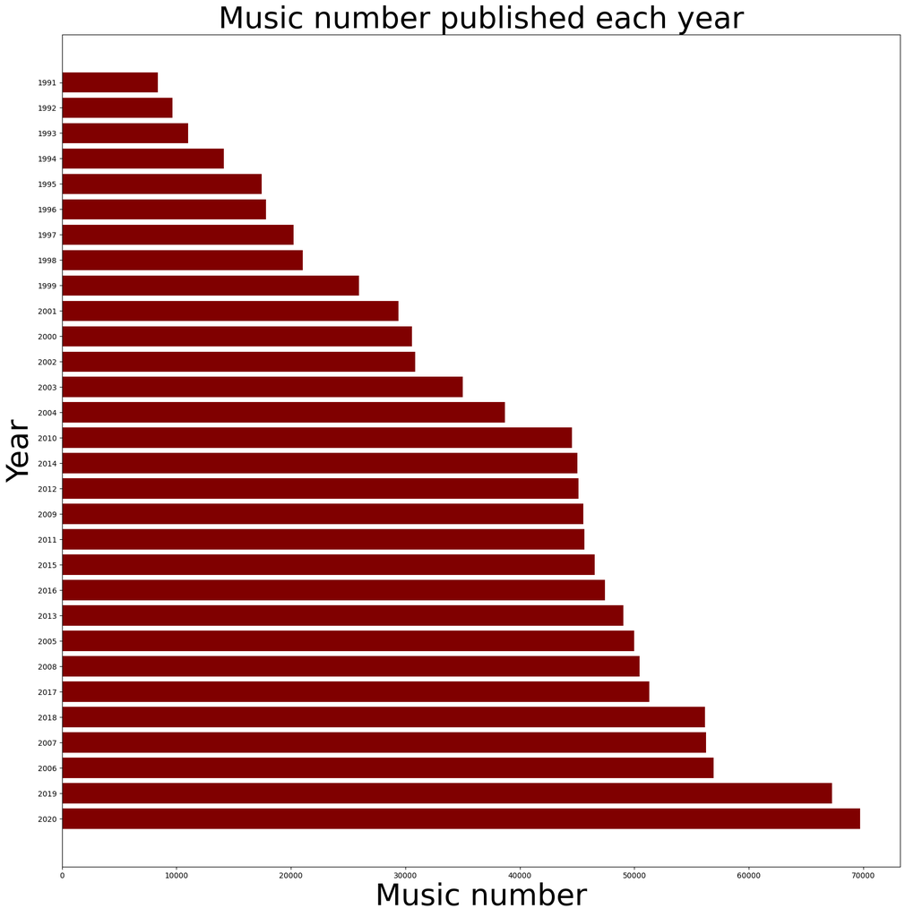

```python
import matplotlib.pyplot as plt
import numpy as np
year = year_counts.select('year').collect()
count_per_year = year_counts.select('count').collect()

year_array = [str(year[i]['year']) for i in range(30)]
count_array = [int(count_per_year[i]['count']) for i in range(30) ]
fig = plt.figure(figsize = (20, 20))

plt.barh(year_array, count_array, color ='maroon')

plt.xlabel("Music number", fontsize=40)
plt.ylabel("Year", fontsize=40)
plt.title("Music number published each year", fontsize=40)
plt.show()
```

### The most influential singer per year

```python
artists_year_count = df.groupBy('artists', 'year').count()
```

```python
artists_year_count[artists_year_count['year'] == 2002].agg(F.max('count')).show()
```

```
+----------+
|max(count)|
+----------+
|       267|
+----------+
```

```python
best_artist_in_year = artists_year_count.groupby('year').agg(
    F.max('count').alias("maximun songs number"),
    F.first('artists').alias("Artist group name with maximun songs in year")
)
```

```python
best_artist_in_year.orderBy(F.desc('maximun songs number')).show()
```

```
+----+--------------------+--------------------------------------------+
|year|maximun songs number|Artist group name with maximun songs in year|
+----+--------------------+--------------------------------------------+
|2013|                 906|                                 ['Alwoods']|
|2007|                 533|                                     ['Mia']|
|2016|                 480|                           ['Jack Cheshire']|
|1995|                 316|                              ['Sean Kelly']|
|2002|                 267|                        ['Tristeza', 'Mar...|
|2019|                 260|                            ['Mike Mershon']|
|2003|                 257|                                   ['Bride']|
|2005|                 256|                           ['Matthew Sweet']|
|2006|                 255|                          ['Chieli Minucci']|
|2018|                 255|                        ['Plasticbag Face...|
|1999|                 224|                        ['Negativland', '...|
|2017|                 215|                          ['Carlene Carter']|
|2014|                 212|                                ['Yum Kaax']|
|1996|                 211|                                ['Boyracer']|
|2008|                 209|                        ['Jill Monroe', '...|
|2015|                 203|                               ['Jireh Lim']|
|2004|                 201|                        ['Schaeben', 'Voss']|
|2011|                 175|                        ['Cy Coleman', 'D...|
|2020|                 172|                        ['Ludwig van Beet...|
|2009|                 146|                              ['Skipinnish']|
+----+--------------------+--------------------------------------------+
only showing top 20 rows
```

### Number of times that each singer had most songs in one year

```python
best_artist_in_year.groupby('Artist group name with maximun songs in year').count().orderBy(F.desc('count')).show()
```

```
+--------------------------------------------+-----+
|Artist group name with maximun songs in year|count|
+--------------------------------------------+-----+
|                            ['Betty Harris']|    4|
|                        ['Daryl Hall & Jo...|    3|
|                            ['Ani DiFranco']|    3|
|                        ['Art Blakey & Th...|    2|
|                        ['Rage Against Th...|    2|
|                               ['Art Tatum']|    2|
|                        ['Reflected Illus...|    2|
|                            ['Cyndi Lauper']|    2|
|                        ['Blue Öyster Cult']|    1|
|                         ['Evie Ladin Band']|    1|
|                               ['Roy Acuff']|    1|
|                        ['Orquesta Felipe...|    1|
|                        ['MGM Studio Orch...|    1|
|                        ['Antonín Dvořák'...|    1|
|                        ['Art Blakey & Th...|    1|
|                        ['Baron Lee', 'Th...|    1|
|                               ['Frog Eyes']|    1|
|                        ['Big Brother & T...|    1|
|                             ['Peter Kater']|    1|
|                           ['Vashti Bunyan']|    1|
+--------------------------------------------+-----+
only showing top 20 rows
```

# Betty Harris

## Four times were The most influential singer

# Alwoods

## Artists group who has maximum number of songs in one year(2013)

### Album with the Most Songs

```python
artists_year_count = df.groupBy('album', 'year').count()
artists_year_count[artists_year_count['year'] == 2002].agg(F.max('count')).show()
```

```
+----------+
|max(count)|
+----------+
|        85|
+----------+
```

```python
best_album_in_year = artists_year_count.groupby('year').agg(
    F.max('count').alias("maximun songs number"),
    F.first('album').alias("Album name with maximun songs in year")
)
```

```python
best_album_in_year.orderBy(F.desc('maximun songs number')).show()
```

```
+----+--------------------+-------------------------------------+
|year|maximun songs number|Album name with maximun songs in year|
+----+--------------------+-------------------------------------+
|2001|                 240|                     Pop Ambient 2002|
|2003|                 180|                   The Burden of Hope|
|1996|                 142|                 Genius + Love = Y...|
|2007|                 127|                      This Journey In|
|2004|                 120|                                   Do|
|1998|                 114|                   Are You Shpongled?|
|1990|                 103|                 Mozart: Piano Con...|
|1997|                 100|                        Conspiracy #5|
|2017|                 100|                 Nielsen: The Orga...|
|2005|                  91|                         Laut & Leise|
|2002|                  85|                       You Were Right|
|1999|                  84|                        Natural Thing|
|2019|                  84|                 Rock 'n' Roll Crazy!|
|1988|                  77|                         Hear No Evil|
|2012|                  77|                              Charmer|
|2008|                  76|                                Lucky|
|1995|                  75|                                Peep!|
|2010|                  71|                     The Dreaming Man|
|2000|                  69|                     South of Stephen|
|2006|                  69|                          Film School|
+----+--------------------+-------------------------------------+
only showing top 20 rows
```

# Pop Ambient 2002

## Album that has maximum number of songs in one year(2001)

# Most musical year

## Num of musics per year

```python
from pyspark.sql.functions import to_date, when, month, year

# Check if the date format is 'yyyy' or 'yyyy-mm-dd' and convert accordingly
df = df.withColumn("release_date", when(df["release_date"].contains("-"), to_date(df["release_date"], "yyyy-MM-dd")).otherwise(to_date(df["release_date"], "yyyy")))

# Extract month and year from 'release_date'
df = df.withColumn("release_month", month(df["release_date"]))
df = df.withColumn("release_year", year(df["release_date"]))

# Get the count of songs released each year
song_count_per_year = df.groupBy("release_year").count().orderBy("release_year")

# Analyze other fields such as danceability, energy, etc.

# Show the results
song_count_per_year.sort(desc("count")).show()
```

```
+------------+-----+
|release_year|count|
+------------+-----+
|        2020|69726|
|        2019|67276|
|        2006|56945|
|        2007|56274|
|        2018|56167|
|        2017|51308|
|        2008|50475|
|        2005|49945|
|        2013|49048|
|        2016|47427|
|        2015|46558|
|        2011|45635|
|        2009|45563|
|        2012|45108|
|        2014|45005|
|        2010|44550|
|        2004|38681|
|        2003|34985|
|        2002|30859|
|        2000|30575|
+------------+-----+
only showing top 20 rows
```

```python
df.describe().show()
```

```
+-------+--------------------+----------+---------------+--------------------+---------------------------+--------------------+-----------------+-------------------+-------------------+-------------------+-----------------+-------------------+-------------------+-------------------+-----------------…
|summary|                  id|      name|          album|            album_id|                    artists|          artist_ids|     track_number|        disc_number|       danceability|             energy|              key|           loudness|               mode|        speechiness|       acousticne…
+-------+--------------------+----------+---------------+--------------------+---------------------------+--------------------+-----------------+-------------------+-------------------+-------------------+-----------------+-------------------+-------------------+-------------------+-----------------…
|  count|             1204025|   1204022|        1204014|             1204025|                    1204025|             1204025|          1204025|            1204025|            1204025|            1204025|          1204025|            1204025|            1204025|            1204025|            12040…
|   mean|                NULL|       NaN|       Infinity|                NULL|                       NULL|                NULL|7.656351819937294| 1.0559058159091381|0.49305652179149567| 0.5095362861749997|5.194151284234131|-11.808702928095125| 0.6714594796619672|0.08438219123357689|0.446751098196852…
| stddev|                NULL|       NaN|            NaN|                NULL|                       NULL|                NULL|5.994977426554823|0.29537516799866304| 0.1896694028575742|0.29468391295221086|3.536730782291117| 6.9821316109798195|0.46968269081835023|0.11599137055178492|0.385201418801080…
|    min|0001Lyv0YTjkZSqzT...|         !|              !|0008WZMLnvEBVnq41...|            ["'63 Burnout"]|['000IaWMr5wgahZN...|                1|                  1|                0.0|                0.0|                0|              -60.0|                  0|                0.0|                0…
|    max|7zzzxEQAsiuIimY7A...|what Baby|행복(Happiness)|7zzz0Fqahwtd6jd2B...|['Ｏｃｅａｎ Ｓｈｏｒｅｓ']|['7zyhnskTdKPIbiA...|               50|                 13|                1.0|                1.0|               11|              7.234|                  1|              0.969|              0.996|           …
+-------+--------------------+----------+---------------+--------------------+---------------------------+--------------------+-----------------+-------------------+-------------------+-------------------+-----------------+-------------------+-------------------+-------------------+-----------------…
```

### The most number of songs for a singer per year

```python
artists_year_count = df.groupBy('artists', 'year').count()
```

```python
artists_year_count[artists_year_count['year'] == 2002].agg(F.max('count')).show()
```

```
+----------+
|max(count)|
+----------+
|       267|
+----------+
```

```python
best_artist_in_year = artists_year_count.groupby('year').agg(
    F.max('count').alias("maximun songs number"),
    F.first('artists').alias("Artist group name with maximun songs in year")
)
```

```python
best_artist_in_year.orderBy(F.desc('maximun songs number')).show()
```

```
+----+--------------------+--------------------------------------------+
|year|maximun songs number|Artist group name with maximun songs in year|
+----+--------------------+--------------------------------------------+
|2013|                 906|                                 ['Alwoods']|
|2007|                 533|                                     ['Mia']|
|2016|                 480|                           ['Jack Cheshire']|
|1995|                 316|                              ['Sean Kelly']|
|2002|                 267|                        ['Tristeza', 'Mar...|
|2019|                 260|                            ['Mike Mershon']|
|2003|                 257|                                   ['Bride']|
|2005|                 256|                           ['Matthew Sweet']|
|2006|                 255|                          ['Chieli Minucci']|
|2018|                 255|                        ['Plasticbag Face...|
|1999|                 224|                        ['Negativland', '...|
|2017|                 215|                          ['Carlene Carter']|
|2014|                 212|                                ['Yum Kaax']|
|1996|                 211|                                ['Boyracer']|
|2008|                 209|                        ['Jill Monroe', '...|
|2015|                 203|                               ['Jireh Lim']|
|2004|                 201|                        ['Schaeben', 'Voss']|
|2011|                 175|                        ['Cy Coleman', 'D...|
|2020|                 172|                        ['Ludwig van Beet...|
|2009|                 146|                              ['Skipinnish']|
+----+--------------------+--------------------------------------------+
only showing top 20 rows
```

### Number of times that each singer had most songs in one year

```python
best_artist_in_year.groupby('Artist group name with maximun songs in year').count().orderBy(F.desc('count')).show()
```

```
+--------------------------------------------+-----+
|Artist group name with maximun songs in year|count|
+--------------------------------------------+-----+
|                            ['Betty Harris']|    4|
|                        ['Daryl Hall & Jo...|    3|
|                            ['Ani DiFranco']|    3|
|                        ['Art Blakey & Th...|    2|
|                        ['Rage Against Th...|    2|
|                               ['Art Tatum']|    2|
|                        ['Reflected Illus...|    2|
|                            ['Cyndi Lauper']|    2|
|                        ['Blue Öyster Cult']|    1|
|                         ['Evie Ladin Band']|    1|
|                               ['Roy Acuff']|    1|
|                        ['Orquesta Felipe...|    1|
|                        ['MGM Studio Orch...|    1|
|                        ['Antonín Dvořák'...|    1|
|                        ['Art Blakey & Th...|    1|
|                        ['Baron Lee', 'Th...|    1|
|                               ['Frog Eyes']|    1|
|                        ['Big Brother & T...|    1|
|                             ['Peter Kater']|    1|
|                           ['Vashti Bunyan']|    1|
+--------------------------------------------+-----+
only showing top 20 rows
```

# Betty Harris

## Four times were The most influential singer

# Alwoods

## Artists group who has maximum number of songs in one year(2013)

### Album with the Most Songs

```python
artists_year_count = df.groupBy('album', 'year').count()
```

```python
artists_year_count[artists_year_count['year'] == 2002].agg(F.max('count')).show()
```

```
+----------+
|max(count)|
+----------+
|        85|
+----------+
```

```python
best_album_in_year = artists_year_count.groupby('year').agg(
    F.max('count').alias("maximun songs number"),
    F.first('album').alias("Album name with maximun songs in year")
)
```

```python
best_album_in_year.orderBy(F.desc('maximun songs number')).show()
```

```
+----+--------------------+-------------------------------------+
|year|maximun songs number|Album name with maximun songs in year|
+----+--------------------+-------------------------------------+
|2001|                 240|                     Pop Ambient 2002|
|2003|                 180|                   The Burden of Hope|
|1996|                 142|                 Genius + Love = Y...|
|2007|                 127|                      This Journey In|
|2004|                 120|                                   Do|
|1998|                 114|                   Are You Shpongled?|
|1990|                 103|                 Mozart: Piano Con...|
|1997|                 100|                        Conspiracy #5|
|2017|                 100|                 Nielsen: The Orga...|
|2005|                  91|                         Laut & Leise|
|2002|                  85|                       You Were Right|
|1999|                  84|                        Natural Thing|
|2019|                  84|                 Rock 'n' Roll Crazy!|
|1988|                  77|                         Hear No Evil|
|2012|                  77|                              Charmer|
|2008|                  76|                                Lucky|
|1995|                  75|                                Peep!|
|2010|                  71|                     The Dreaming Man|
|2000|                  69|                     South of Stephen|
|2006|                  69|                          Film School|
+----+--------------------+-------------------------------------+
only showing top 20 rows
```

# Pop Ambient 2002

## Album that has maximum number of songs in one year(2001)

### Checking destribiotion of some parameters for the past forty years,

```python
artists_energy = df.groupBy('artists', 'energy').count()
```

```python
artists_energy.show()
```

```
+--------------------+------------------+-----+
|             artists|            energy|count|
+--------------------+------------------+-----+
|          ['Zorras']|0.1009999999999999|    1|
|['Reflected Illus...|             0.975|    1|
|    ['Juan Gabriel']|             0.604|    2|
|         ['Unwound']|             0.951|    3|
|    ['William Hung']|             0.444|    1|
|    ['William Hung']|0.7020000000000001|    1|
| ['Scottt Catolico']|            0.0749|    1|
|['Bad Brains', 'D...|             0.902|    1|
|    ['The Shallows']|             0.805|    1|
|['José Alfredo Ji...|             0.187|    2|
|      ['The Ataris']|0.8320000000000001|    1|
|       ['Third Day']|             0.337|    1|
|['Max Bruch', 'An...|            0.0563|    1|
|      ['Cul De Sac']|              0.16|    1|
|             ['Nym']|             0.408|    1|
|     ['Patti Smith']|              0.46|    1|
|['The Dillinger E...|             0.987|    1|
|   ['Kenny Chesney']|             0.314|    1|
|   ['spencer albee']|             0.696|    1|
|   ['Vashti Bunyan']|0.0579999999999999|    1|
+--------------------+------------------+-----+
only showing top 20 rows
```

```python
avg_energy_per_year = df.groupBy('year').agg(F.avg('energy').alias('energy_avg'))
avg_dance_per_year = df.groupBy('year').agg(F.avg('danceability').alias('dance_avg'))
avg_inst_per_year = df.groupBy('year').agg(F.avg('instrumentalness').alias('inst_avg'))
avg_live_per_year = df.groupBy('year').agg(F.avg('liveness').alias('live_avg'))
avg_valence_per_year = df.groupBy('year').agg(F.avg('valence').alias('valence_avg'))
```

```python
avg_energy_per_year = avg_energy_per_year.orderBy('year')
avg_dance_per_year = avg_dance_per_year.orderBy('year')
avg_inst_per_year = avg_inst_per_year.orderBy('year')
avg_live_per_year = avg_live_per_year.orderBy('year')
avg_valence_per_year = avg_valence_per_year.orderBy('year')
```

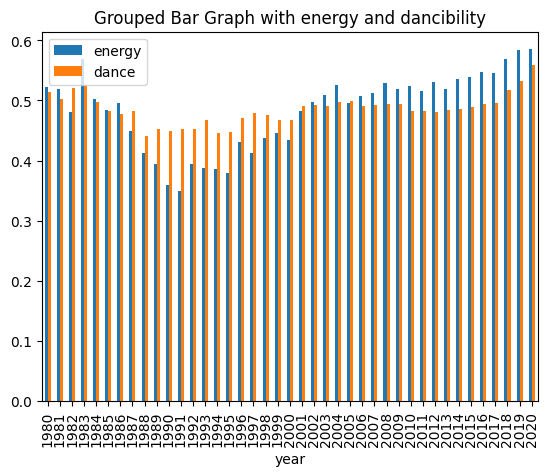

```python
import matplotlib.pyplot as plt
import numpy as np
import pandas as pd

year = avg_energy_per_year.select('year').collect()
energy_per_year = avg_energy_per_year.select('energy_avg').collect()
dance_per_year = avg_dance_per_year.select('dance_avg').collect()
inst_per_year = avg_inst_per_year.select('inst_avg').collect()
live_per_year = avg_live_per_year.select('live_avg').collect()
valence_per_year = avg_valence_per_year.select('valence_avg').collect()
first_index= 60
year_array = [str(year[i]['year']) for i in range(first_index, len(year))]
energy_array = [(energy_per_year[i]['energy_avg']) for i in range(first_index, len(year)) ]
dance_array = [(dance_per_year[i]['dance_avg']) for i in range(first_index, len(year)) ]
inst_array = [(inst_per_year[i]['inst_avg']) for i in range(first_index, len(year)) ]
live_array = [(live_per_year[i]['live_avg']) for i in range(first_index, len(year)) ]
valence_array = [(valence_per_year[i]['valence_avg']) for i in range(first_index, len(year)) ]

arrays = []
for i in range(len(year_array)):
    arrays.append([year_array[i], energy_array[i], dance_array[i]])

df_ = pd.DataFrame(arrays,
                  columns=["year", "energy", "dance"])

df_.plot(x='year',
        kind='bar',
        stacked=False,
        title='Grouped Bar Graph with energy and dancibility')
```

We see correlation between energy and dancibility.

Dancibility didn't chenged more during time but energy changed.

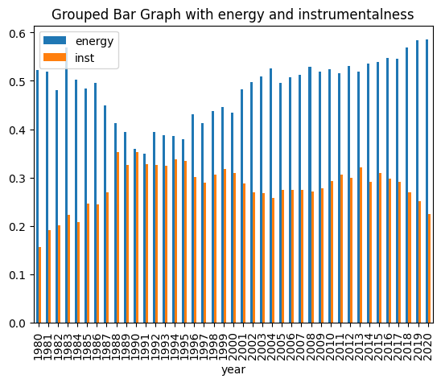

```python
arrays = []
for i in range(len(year_array)):
    arrays.append([year_array[i], energy_array[i], inst_array[i]])

df_ = pd.DataFrame(arrays,
                  columns=["year", "energy", "inst"])

df_.plot(x='year',
        kind='bar',
        stacked=False,
        title='Grouped Bar Graph with energy and instrumentalness')
```

It shows we have negetive correlation between instrumentalness and energy.

instrumentalness destribiotion is like normal distribiotion.

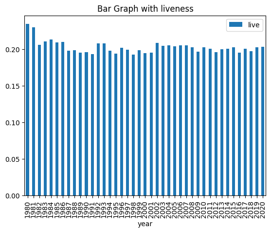

```python
arrays = []
for i in range(len(year_array)):
    arrays.append([year_array[i], live_array[i]])

df_ = pd.DataFrame(arrays,
                  columns=["year", "live"])

df_.plot(x='year',
        kind='bar',
        stacked=False,
        title='Bar Graph with liveness')
```

Almost liveness didn't changed during years.

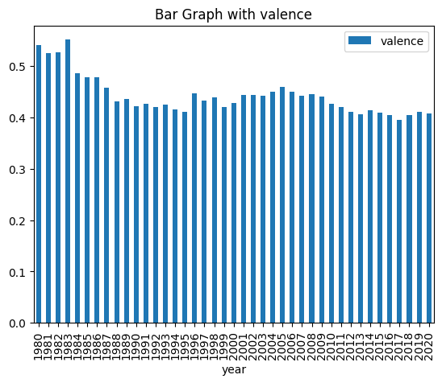

```python
arrays = []
for i in range(len(year_array)):
    arrays.append([year_array[i], valence_array[i]])

df_ = pd.DataFrame(arrays,
                  columns=["year", "valence"])

df_.plot(x='year',
        kind='bar',
        stacked=False,
        title='Bar Graph with valence')
```

Valence measure destribiotion is descending and it is bad.

Also increasing energy and dancibility, positiveness in songs decreased.

It is strange.

```python
df = df.withColumn('month', month(df['release_date']))

# Group by 'month' and compute the average values for tempo, danceability, and other factors
monthly_avg_stats = df.groupBy('month').avg('tempo', 'danceability', 'energy', 'loudness', 'speechiness',
                                            'acousticness', 'instrumentalness', 'liveness', 'valence')


# Show the aggregated statistics for each month
monthly_avg_stats.show()
```

```
+-----+------------------+-------------------+------------------+-------------------+-------------------+-------------------+---------------------+-------------------+-------------------+
|month|        avg(tempo)|  avg(danceability)|       avg(energy)|      avg(loudness)|   avg(speechiness)|  avg(acousticness)|avg(instrumentalness)|      avg(liveness)|       avg(valence)|
+-----+------------------+-------------------+------------------+-------------------+-------------------+-------------------+---------------------+-------------------+-------------------+
|   12|118.51844091466204| 0.5038889103220977|0.5258596612433906| -11.43688068398731|0.08841967367934618| 0.4171060289083107|   0.3005895191339661| 0.2006741354712953| 0.4147591068378661|
| NULL| 117.6216872623574| 0.4872346007604563|0.5097590399239541| -12.27771007604565|0.06778003802281377|0.43859552367870747|  0.12602075903041804| 0.2582442015209129| 0.5095264258555132|
|    1| 116.8435617503123| 0.4814846130171547|0.4750068647003908|-12.720698170790957|0.07828533442046066|0.49292665501513727|   0.2846694691818764|0.19839494705090563|0.43990797117609826|
|    6|117.56303893411273| 0.4952534216075521|0.5149743616560821|-11.644079918008517|0.08371209254655751| 0.4429023445823178|  0.28747573444979774|0.20065083028025377| 0.4338335984308503|
|    3|118.01290139294919| 0.4935445792415222|0.5202161765852603|-11.665427680416789|0.08344871895216706|0.43071285211632365|  0.28464393575669966|0.19842519952548973|  0.426150991940706|
|    5|118.26566151462723| 0.4975221307275235|0.5238783744145874|-11.493854698206617|0.08399973067985168| 0.4328116201781541|   0.2868048214244169| 0.1983833474349061|0.42824279485192723|
|    9|117.76107603189199| 0.4971376753267905|0.5169481873764671|-11.506137853230038|0.08602694039159997|0.43433319141172594|    0.282305815331127| 0.1998828273580295|0.41897453490263975|
|    4|118.12501019150237|0.49534660018796495|0.5232828882376689| -11.41245709194334| 0.0836004625843666|  0.429342887903479|   0.2826681377550564|0.20100746725903598| 0.4295409156485289|
|    8|117.86489139448562| 0.4993603123728064|0.5246128948120119|-11.409063555657296|0.08945932412494596|0.42697480980604746|   0.2787456516768394|0.20470364608770777|0.42413034645909775|
|    7|118.34050632538593| 0.5014093323983149|0.5416297601949478|-11.070453197756063| 0.0900494263674597| 0.4068570020405281|   0.2820854578835917|0.20516524684431875|0.43072843253856957|
|   10|117.83509315042474| 0.5006432097593342|0.5229912120055107| -11.36200891441583|0.08918803341718982|0.42496064356320473|  0.26721199492257824| 0.2039060805999882|  0.419877382085723|
|   11|117.69467849670865| 0.4952672407338077|0.5183572566707819|-11.507039410223111| 0.0902165525139242| 0.4376282603602901|   0.2680113416549207|0.21402594952320364|0.41566959796947517|
|    2|117.30916516050414|  0.490307996063642|0.5076216011642701|-11.891783736208755|0.08364459167267049|0.44755154160184885|   0.3008144728916942|0.20059701169817504| 0.4181387597161408|
+-----+------------------+-------------------+------------------+-------------------+-------------------+-------------------+---------------------+-------------------+-------------------+
```

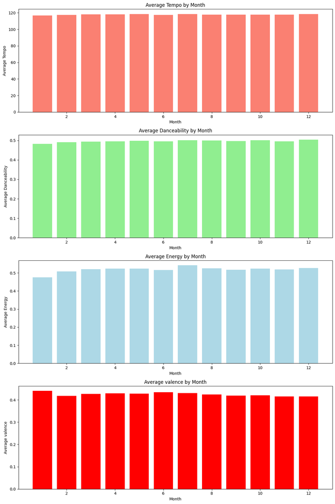

```python
monthly_avg_stats_pd = monthly_avg_stats.toPandas()

# Sort the data by 'month' for better visualization
monthly_avg_stats_pd = monthly_avg_stats_pd.sort_values('month')

# Create a figure with subplots for each attribute
fig, axs = plt.subplots(4, 1, figsize=(12, 18))

# Plot average tempo
axs[0].bar(monthly_avg_stats_pd['month'], monthly_avg_stats_pd['avg(tempo)'], color='salmon')
axs[0].set_title('Average Tempo by Month')
axs[0].set_xlabel('Month')
axs[0].set_ylabel('Average Tempo')

# Plot average danceability
axs[1].bar(monthly_avg_stats_pd['month'], monthly_avg_stats_pd['avg(danceability)'], color='lightgreen')
axs[1].set_title('Average Danceability by Month')
axs[1].set_xlabel('Month')
axs[1].set_ylabel('Average Danceability')

# Plot average energy
axs[2].bar(monthly_avg_stats_pd['month'], monthly_avg_stats_pd['avg(energy)'], color='lightblue')
axs[2].set_title('Average Energy by Month')
axs[2].set_xlabel('Month')
axs[2].set_ylabel('Average Energy')

# Plot average energy
axs[3].bar(monthly_avg_stats_pd['month'], monthly_avg_stats_pd['avg(valence)'], color='red')
axs[3].set_title('Average valence by Month')
axs[3].set_xlabel('Month')
axs[3].set_ylabel('Average valence')

# Adjust layout and display the plots
plt.tight_layout()
plt.show()
```

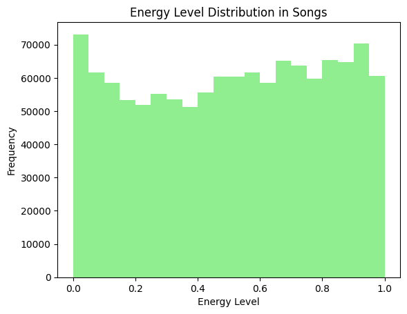

```python
from pyspark.sql.functions import col

# Calculate the distribution of energy levels
energy_distribution = df.select('energy').rdd.flatMap(lambda x: x).collect()

# Plotting the distribution of energy levels
plt.hist(energy_distribution, bins=20, color='lightgreen')
plt.xlabel('Energy Level')
plt.ylabel('Frequency')
plt.title('Energy Level Distribution in Songs')
plt.show()
```

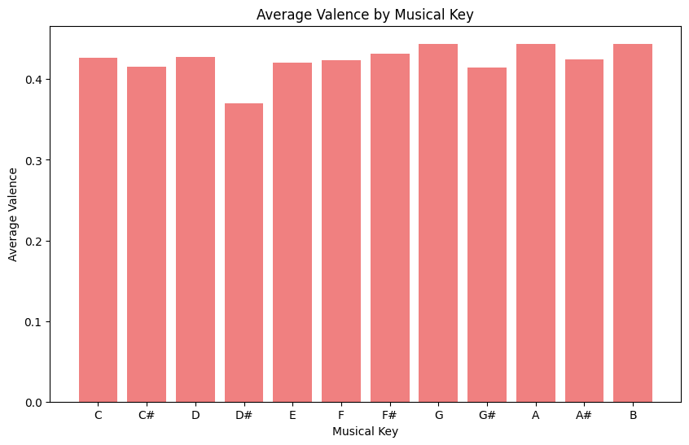

```python
key_valence_analysis = df.groupBy('key').agg({'valence': 'mean'}).orderBy('key').toPandas()

# Plotting the average valence by musical key
plt.figure(figsize=(10, 6))
plt.bar(key_valence_analysis['key'], key_valence_analysis['avg(valence)'], color='lightcoral')
plt.xlabel('Musical Key')
plt.ylabel('Average Valence')
plt.title('Average Valence by Musical Key')
plt.xticks(range(0, 12), ['C', 'C#', 'D', 'D#', 'E', 'F', 'F#', 'G', 'G#', 'A', 'A#', 'B'])
plt.show()
```

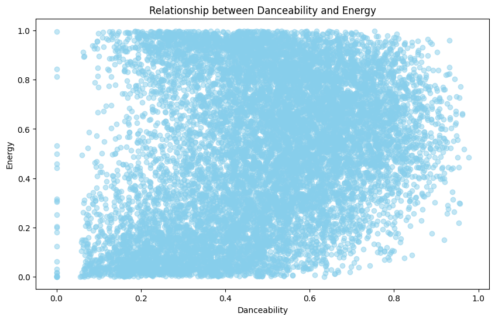

```python
import matplotlib.pyplot as plt

# Sample a subset of data for scatter plot
df_sample = df.select('danceability', 'energy').sample(False, 0.01)  # Sample data for faster plotting

# Collect the sampled data as a list of rows
danceability_energy_data = df_sample.collect()

# Extract danceability and energy values from the collected data
danceability = [row.danceability for row in danceability_energy_data]
energy = [row.energy for row in danceability_energy_data]

# Create a scatter plot of danceability vs. energy
plt.figure(figsize=(10, 6))
plt.scatter(danceability, energy, color='skyblue', alpha=0.5)
plt.xlabel('Danceability')
plt.ylabel('Energy')
plt.title('Relationship between Danceability and Energy')
plt.show()
```

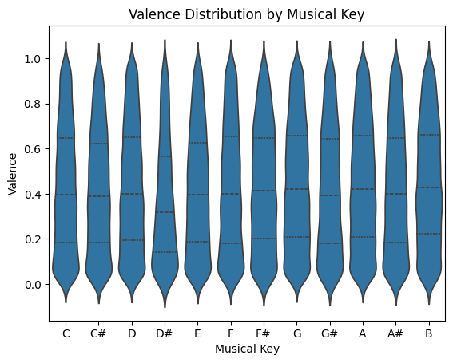

```python
import seaborn as sns
sample_df = df.sample(fraction=0.1, withReplacement=False)  # Sample a fraction of the data for plotting
sample_data = sample_df.select('key', 'valence').toPandas()
sns.violinplot(x='key', y='valence', data=sample_data, scale='width', inner='quartile')

plt.xlabel('Musical Key')
plt.ylabel('Valence')
plt.title('Valence Distribution by Musical Key')
plt.xticks(range(0, 12), ['C', 'C#', 'D', 'D#', 'E', 'F', 'F#', 'G', 'G#', 'A', 'A#', 'B'])
plt.show()
```

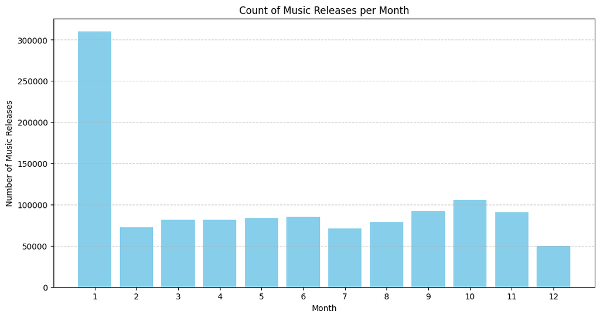

```python
import matplotlib.pyplot as plt
from pyspark.sql import SparkSession
from pyspark.sql.functions import count, month
from pyspark.sql.types import IntegerType


df = df.withColumn('month', month(df['release_date']).cast(IntegerType()))

# Group by 'month' and count the number of music releases in each month
monthly_music_count = df.groupBy('month').agg(count('id').alias('count')).orderBy('month')

# Collect the data to the driver node
months = monthly_music_count.select('month').rdd.flatMap(lambda x: x).collect()
counts = monthly_music_count.select('count').rdd.flatMap(lambda x: x).collect()

# Create a bar plot to show the count of music releases for each month
plt.figure(figsize=(12, 6))
plt.bar(months, counts, color='skyblue')
plt.xlabel('Month')
plt.ylabel('Number of Music Releases')
plt.title('Count of Music Releases per Month')
plt.xticks(months)
plt.grid(axis='y', linestyle='--', alpha=0.6)
plt.show()
```

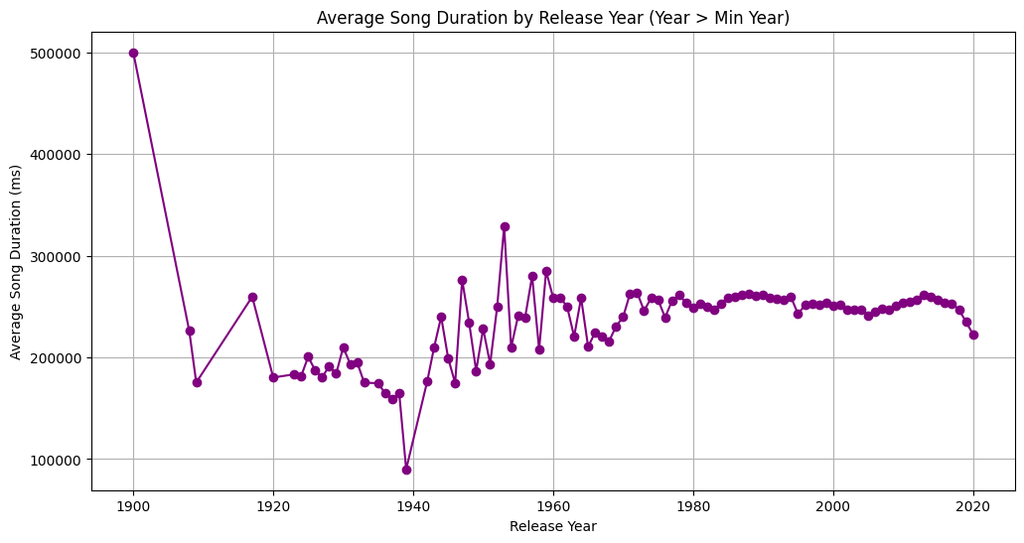

```python
from pyspark.sql.functions import mean, min
min_year = df.select(min('year')).first()[0]
filtered_data = df.filter(df['year'] > min_year)
duration_by_year = filtered_data.groupBy('year').agg(mean('duration_ms').alias('avg_duration_ms')).orderBy('year')
year_list = duration_by_year.select('year').rdd.flatMap(lambda x: x).collect()
avg_duration_list = duration_by_year.select('avg_duration_ms').rdd.flatMap(lambda x: x).collect()

# Plot the average song duration by release year
plt.figure(figsize=(12, 6))
plt.plot(year_list, avg_duration_list, marker='o', color='purple')
plt.xlabel('Release Year')
plt.ylabel('Average Song Duration (ms)')
plt.title('Average Song Duration by Release Year (Year > Min Year)')
plt.grid(True)
plt.show()
```

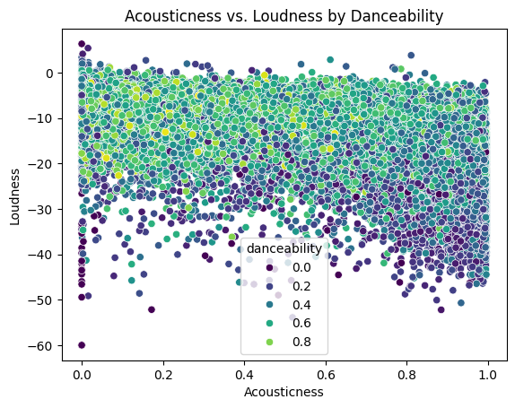

```python
import seaborn as sns
import matplotlib.pyplot as plt

# Sample data for faster plotting
sample_df = df.sample(fraction=0.1, withReplacement=False)

# Create a scatter plot of acousticness vs. loudness by danceability without converting to Pandas
sns.scatterplot(x='acousticness', y='loudness', hue='danceability', data=sample_df.toPandas(), palette='viridis')

plt.xlabel('Acousticness')
plt.ylabel('Loudness')
plt.title('Acousticness vs. Loudness by Danceability')
plt.show()
```

```python
from pyspark.sql.functions import avg
artist_valence_avg = df.groupBy('artists').agg(avg('valence').alias('avg_valence'))

# Find the happiest singer
happiest_singer = artist_valence_avg.orderBy('avg_valence', ascending=False).first()

# Find the saddest singer
saddest_singer = artist_valence_avg.orderBy('avg_valence').first()

print("Happiest Singer:", happiest_singer['artists'], "- Average Valence:", happiest_singer['avg_valence'])
print("Saddest Singer:", saddest_singer['artists'], "- Average Valence:", saddest_singer['avg_valence'])
```

```
Happiest Singer: ['Gerry Wimsey'] - Average Valence: 1.0
Saddest Singer: ['Rod Kimble'] - Average Valence: 0.0
```

```python
from pyspark.sql import SparkSession
from pyspark.sql.functions import countDistinct, count, col

most_frequent_artist = df.groupBy('artists').count().orderBy('count', ascending=False).first()
print("Artist that sings the most in a group:", most_frequent_artist['artists'])

# Artist with the Most Increase and Decrease in Number of Songs
artist_song_count = df.groupBy('artists', 'year').agg(count('id').alias('num_songs'))
artist_max_songs = artist_song_count.groupBy('artists').agg(
    (countDistinct('year')).alias('num_years'),
    count('year').alias('num_total_songs')
).orderBy('num_total_songs', ascending=False)
most_songs_artist = artist_max_songs.first()
least_songs_artist = artist_max_songs.orderBy('num_total_songs').first()
print("Artist with the most increase in songs:", most_songs_artist['artists'])
print("Artist with the most decrease in songs:", least_songs_artist['artists'])

# Artist that Sings for the Most Years
most_years_artist = artist_max_songs.orderBy('num_years', ascending=False).first()
print("Artist that sings for the most years:", most_years_artist['artists'])
```

```
Artist that sings the most in a group: ['Various Artists']
Artist with the most increase in songs: ['Aretha Franklin']
Artist with the most decrease in songs: ['DJ Drama', 'Travis Porter', 'Kirko Bangz']
Artist that sings for the most years: ['Aretha Franklin']
```

# Question1: Read about how Spark and Hadoop work. What does the term ‘lazy evaluation’ mean for them? Explain with a simple example.

In both Hadoop and Spark, lazy evaluation refers to a similar concept, though they implement it differently.

In **`Hadoop`** MapReduce, lazy evaluation primarily refers to the fact that the actual processing of data happens only when a job is submitted and not during the entire chain of MapReduce operations. The intermediate data generated by each Map and Reduce operation is written to disk, and the subsequent operation starts only when the previous one completes. This approach allows Hadoop to optimize resource usage and handle large datasets efficiently.

In **`Spark`**, lazy evaluation is a core feature of its processing model. When you define transformations on your data, Spark doesn't immediately execute them. Instead, it builds up a directed acyclic graph (DAG) of transformations. Only when an action is called, such as `collect()` or `saveAsTextFile()`, does Spark execute the transformations needed to produce the final result.

Here's a simple example to illustrate lazy evaluation in Spark:

Suppose we have a text file containing lines of text, and we want to count the number of lines that contain a specific word.

```
# Initialize SparkSession
from pyspark.sql import SparkSession
spark = SparkSession.builder \
    .appName("LazyEvaluationExample") \
    .getOrCreate()

# Load the text file into an RDD (Resilient Distributed Dataset)
lines = spark.sparkContext.textFile("textfile.txt")

# Define transformation: Filter lines containing a specific word
filtered_lines = lines.filter(lambda line: "word" in line)

# Define action: Count the number of lines
line_count = filtered_lines.count()

# Print the result
print("Number of lines containing 'word':", line_count)
```

In this example, even though we've defined the transformation to filter lines containing the word "word", Spark doesn't execute it immediately. It only computes the result when the action `count()` is called.

This lazy evaluation approach allows Spark to optimize the sequence of operations and avoid unnecessary computations, resulting in better performance and resource utilization, especially when dealing with large-scale data processing tasks.

# Question2: Your main task’s dataset has about 1,200,000 rows, which makes it quite hard, and even sometimes impossible, to work with. Explain how parquet files try to solve this problem, compared to normal file formats like csv.

1. **Columnar Storage**: Parquet files store data in a columnar format, meaning that values from the same column are stored together. In contrast, CSV files store data in a row-based format, where each row contains values for all columns. With columnar storage, Parquet files are optimized for analytical queries that typically involve accessing a subset of columns, resulting in reduced I/O overhead and improved query performance.
2. **Compression**: Parquet files support various compression algorithms like Snappy, Gzip, and LZ4. By compressing data at the column level, Parquet files can achieve better compression ratios compared to compressing entire rows, as similar values within a column tend to compress more efficiently. This results in reduced storage requirements and faster data transfer speeds, especially when reading from and writing to disk.
3. **Predicate Pushdown**: Parquet files support predicate pushdown, a technique where filtering operations are pushed down to the storage layer. When querying Parquet files, the query engine can skip reading entire chunks of data based on the filter conditions, thus reducing the amount of data that needs to be processed and improving query performance. This is particularly advantageous for analytical workloads where filtering is common.
4. **Schema Evolution**: Parquet files store schema information along with the data, allowing for flexible schema evolution without requiring modifications to existing data. This is beneficial in scenarios where schemas may change over time, as it enables seamless compatibility between different versions of the schema and simplifies data management and migration tasks.
5. **Partitioning**: Parquet files can be partitioned based on one or more columns, such as date or category. Partitioning organizes data into directory structures based on the partition columns, which can significantly improve query performance by allowing the query engine to skip entire partitions that don't satisfy the query predicates. This is particularly useful for datasets with large volumes of data, as it reduces the amount of data that needs to be scanned during query execution.

Overall, Parquet files provide a more efficient and scalable solution for handling large datasets compared to traditional file formats like CSV. By leveraging columnar storage, compression, predicate pushdown, schema evolution, and partitioning, Parquet files offer improved storage efficiency, faster query performance, and better support for analytical workloads.

# Question3: As you might have noticed, Spark doesn’t save checkpoints. How can we enforce it to do so? This can help us if we have multiple computation steps and we don’t want to wait a lot for the result.

In Apache Spark, checkpointing is a mechanism used to persist the intermediate RDDs (Resilient Distributed Datasets) to a reliable storage system like HDFS (Hadoop Distributed File System) or Amazon S3. This helps in fault tolerance and optimization of lineage information, especially in long DAGs (Directed Acyclic Graphs) of transformations, thus improving the reliability and performance of Spark jobs.

By default, Spark does not save checkpoints automatically. However, you can enforce Spark to save checkpoints by explicitly instructing it to do so using the `checkpoint()` method on an RDD. Here's how you can enforce checkpointing in Spark:

1. **Enable Checkpointing**: Before you can enforce checkpointing, you need to enable it by specifying the checkpoint directory. This is typically done using the `SparkContext` object.

   ```
   from pyspark import SparkContext

    sc = SparkContext("local", "CheckpointExample")
    sc.setCheckpointDir("hdfs://path/to/checkpoint/directory")
   ```

   Replace `"hdfs://path/to/checkpoint/directory"` with the desired location where Spark should save the checkpoint data.
2. **Enforce Checkpointing**: Once checkpointing is enabled, you can enforce it on an RDD by calling the `checkpoint()` method.

   ```
   # Create an RDD
    rdd = sc.parallelize(range(1000))

    # Apply transformations
    transformed_rdd = rdd.map(lambda x: x * 2).filter(lambda x: x % 3 == 0)

    # Enforce checkpointing
    transformed_rdd.checkpoint()
   ```

   After this, whenever an action is performed on `transformed_rdd`, Spark will save the checkpoint data to the specified checkpoint directory.

It's important to note a few things about checkpointing in Spark:

- Checkpointing is a costly operation as it involves writing data to disk. Therefore, it should be used judiciously, especially for long lineage chains or in situations where fault tolerance is crucial.
- Enforcing checkpointing on an RDD breaks the lineage information, meaning that subsequent actions on that RDD will not recompute the lineage from the source RDD, but rather load the data from the checkpoint directory.
- Checkpointing is typically used in conjunction with actions that trigger a shuffle operation or when the lineage becomes too long to optimize computation.

# Question4: Top companies stream their data on a regular routine, e.g. daily. How can we save data, so that we could filter it based on specific columns, e.g. date, faster than regular filtering?

To efficiently filter streaming data based on specific columns like date, especially in scenarios where data is streamed regularly (e.g., daily), you can employ partitioning techniques. Partitioning involves organizing data into logical partitions based on specific criteria, such as date in your case. By partitioning the data based on date, you can significantly speed up filtering operations because the system can directly access the relevant partition without scanning the entire dataset.

Here's how you can achieve this:

1. **Partitioning by Date**: When you receive streaming data, partition it based on the date column. For example, if you're using a distributed file system like HDFS or cloud storage like Amazon S3, you can organize the data into directories or folders where each folder represents data for a specific date. Similarly, if you're using a database, you can partition the tables based on the date column.
2. **Use Partition Pruning**: When querying the data, specify the date range you're interested in. Because the data is partitioned by date, the system can prune the partitions that don't contain data within the specified date range, thus reducing the amount of data that needs to be scanned.
3. **Optimize Data Storage Format**: Choose a data storage format that supports efficient partition pruning and filtering, such as Parquet or ORC (Optimized Row Columnar). These columnar storage formats store metadata about partitions, enabling the query engine to skip reading entire partitions that don't satisfy the filter conditions.
4. **Leverage Indexes**: If you're using a database management system (DBMS), consider creating indexes on the date column. Indexes can speed up filtering operations by allowing the system to quickly locate rows that match the filter criteria.
5. **Use Stream Processing Frameworks**: If you're working with real-time streaming data, consider using stream processing frameworks like Apache Kafka Streams or Apache Flink. These frameworks provide built-in support for windowing operations, allowing you to process and filter data based on time windows or specific time intervals efficiently.

By employing these techniques, you can save streaming data in a way that allows for fast and efficient filtering based on specific columns like date, even as the volume of data grows over time.

# Question5: When does each library( Pandas and PySpark ) truly shine, and why? Consider factors like data size, processing complexity, and user experience.

Both Pandas and PySpark are powerful tools for data manipulation and analysis, but they excel in different scenarios due to their design, scalability, and performance characteristics. Here's a breakdown of when each library truly shines:

**Pandas:**

1. **Data Size**: Pandas is most suitable for working with medium-sized datasets that can fit into memory on a single machine. It's optimized for in-memory processing, making it incredibly fast for operations on datasets that are small enough to be loaded into RAM.
2. **Processing Complexity**: Pandas is excellent for complex data manipulation tasks, such as filtering, grouping, joining, and aggregating data. Its rich set of functions and intuitive syntax make it easy to perform complex data transformations and analysis efficiently.
3. **User Experience**: Pandas provides a user-friendly interface with expressive syntax and extensive documentation. It's widely used in the Python data science ecosystem, and many developers are familiar with its API, making it easy to get started and collaborate on projects.
4. **Interactive Data Exploration**: Pandas is well-suited for interactive data exploration and analysis tasks, thanks to its interactive data structures (like DataFrames) and built-in support for visualization libraries like Matplotlib and Seaborn.

**PySpark:**

1. **Data Size**: PySpark shines when dealing with large-scale datasets that exceed the memory capacity of a single machine. It's designed to distribute data processing across a cluster of machines, allowing it to handle massive datasets that can't fit into memory on a single node.
2. **Processing Complexity**: PySpark is particularly well-suited for complex data processing tasks that require distributed computation, such as machine learning, graph processing, and iterative algorithms. Its RDD and DataFrame APIs provide powerful abstractions for expressing complex data transformations and analytics workflows.
3. **Scalability**: PySpark's distributed processing capabilities make it highly scalable, allowing it to scale out to handle petabytes of data across a cluster of machines. It leverages the Hadoop ecosystem for distributed storage and processing, enabling seamless integration with tools like HDFS, Hive, and HBase.
4. **Performance**: While PySpark may not be as fast as Pandas for small to medium-sized datasets due to the overhead of distributed computing, it offers excellent performance scalability as data size and processing complexity increase. It's particularly well-suited for batch processing and large-scale ETL (Extract, Transform, Load) jobs.

In summary, Pandas is best suited for interactive data analysis and manipulation on medium-sized datasets that fit into memory, while PySpark excels in handling large-scale distributed data processing tasks that require scalability, fault tolerance, and parallelism across a cluster of machines. The choice between the two depends on the specific requirements of the data analysis tasks, including data size, processing complexity, and scalability needs.